# IODS course project

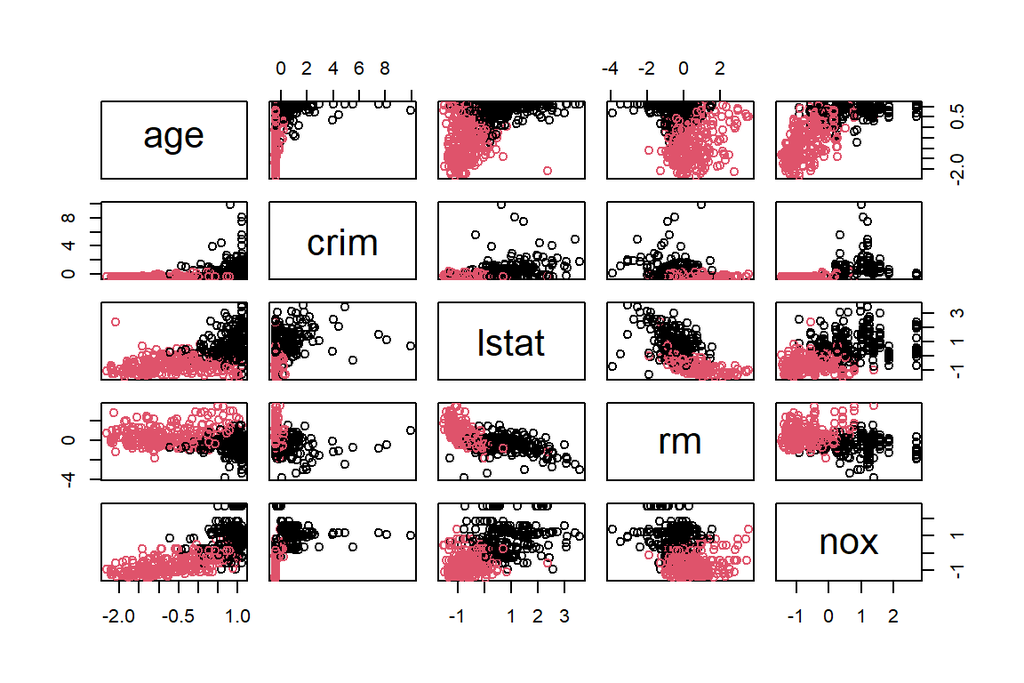

```r
# Let's look at a few variables to get readable plots:
km <- kmeans(boston_scaled[c("age", "crim", "lstat", "rm", "nox")], centers = 2)
pairs(boston_scaled[c("age", "crim", "lstat", "rm", "nox")], col = km$cluster)
```

From the plots it can be seen that the data is rather clustered to two clusters, indicated by the red and black colours.

Let’s start with the Bonus assignments as well, I’ll see how much I can manage (clock is ticking and deadline is approaching - in the last minute again :) )

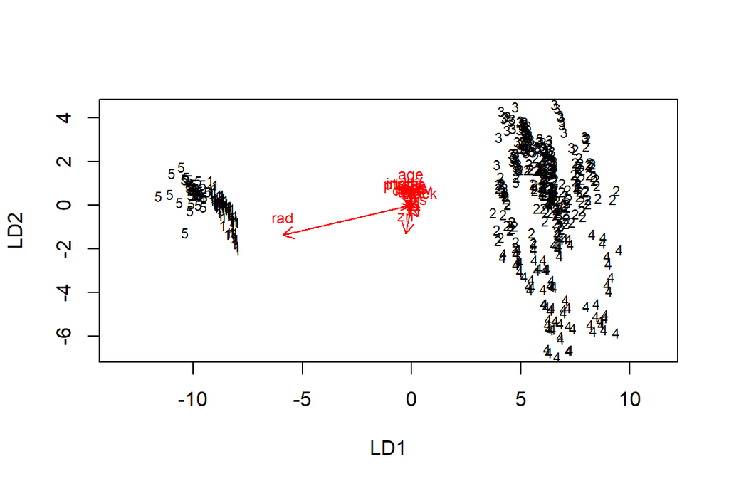

```r
# Scaling the data
boston_scaled <- scale(Boston)
boston_scaled <- as.data.frame(boston_scaled)
# Calculating k-means
kmeans <- kmeans(boston_scaled, centers = 5)
boston_scaled$cluster <- factor(kmeans$cluster)
# LDA analysis
lda_fit <- lda(cluster ~ ., data = boston_scaled)
# Running the function for lda biplot arrows
lda.arrows <- function(x, myscale = 1, arrow_heads = 0.1, color = "red", tex = 0.75, choices = c(1,2)){
  heads <- coef(x)
  graphics::arrows(x0 = 0, y0 = 0,
         x1 = myscale * heads[,choices[1]],
         y1 = myscale * heads[,choices[2]], col=color, length = arrow_heads)
  text(myscale * heads[,choices], labels = row.names(heads),
       cex = tex, col=color, pos=3)
}

# plot the lda (bi)plot
plot(lda_fit, dimen =2)
lda.arrows(lda_fit, myscale = 1)
```

```r
# Checking the coefficients
lda_fit$scaling
```

```
##                 LD1          LD2          LD3          LD4
## crim    -0.19407721 -0.108424007  0.738733174  0.197238539
## zn      -0.27931728 -1.294257874  0.208120000 -1.276931426
## indus   -0.27961952  0.223381654 -0.075900007 -0.674673960
## chas     0.02421115 -0.002695386  0.009041415 -0.227818053
## nox      0.05357905  0.056627298 -0.337390881 -0.391749348
## rm       0.03754630 -0.175650699  0.123350809  0.169280053
## age     -0.03326083  0.626911213 -0.102442690 -0.185885263
## dis      0.29022624 -0.538073937 -0.048017817  0.002670516
## rad     -5.87543331 -1.364143499 -1.200818663  1.379304415
## tax     -0.19217410 -0.178678059 -0.044866141 -0.846137117
## ptratio -0.28646287  0.169622376  0.078959579 -0.312341541
## black    0.35939233 -0.247126286 -2.057713114 -0.104850999
## lstat   -0.08809470  0.200729300  0.163503627 -0.387393704
## medv     0.07528419 -0.075962326  0.014708781  0.019759185
```

# Chapter 5 Dimensionality reduction techniques

```r
date()
```

```
## [1] "Mon Dec 11 21:54:32 2023"
```

*Move the country names to rownames (see Exercise 5.5). Show a graphical overview of the data and show summaries of the variables in the data. Describe and interpret the outputs, commenting on the distributions of the variables and the relationships between them. (0-3 points)*

```r
# Read the data
human <- read.csv("~/IODS-project/data/human.csv")
# First, let's get an overview of the data
names(human)
```

```
##  [1] "X"         "Country"   "Edu2.FM"   "Labo.FM"   "Edu.Exp"   "Life.Exp"
##  [7] "GNI"       "Mat.Mor"   "Ado.Birth" "Parli.F"
```

```r
summary(human)
```

```
##        X           Country             Edu2.FM          Labo.FM
##  Min.   :  1.0   Length:155         Min.   :0.1717   Min.   :0.1857
##  1st Qu.: 39.5   Class :character   1st Qu.:0.7264   1st Qu.:0.5984
##  Median : 78.0   Mode  :character   Median :0.9375   Median :0.7535
##  Mean   : 78.0                      Mean   :0.8529   Mean   :0.7074
##  3rd Qu.:116.5                      3rd Qu.:0.9968   3rd Qu.:0.8535
##  Max.   :155.0                      Max.   :1.4967   Max.   :1.0380
##     Edu.Exp         Life.Exp          GNI            Mat.Mor
##  Min.   : 5.40   Min.   :49.00   Min.   :   581   Min.   :   1.0
##  1st Qu.:11.25   1st Qu.:66.30   1st Qu.:  4198   1st Qu.:  11.5
##  Median :13.50   Median :74.20   Median : 12040   Median :  49.0
##  Mean   :13.18   Mean   :71.65   Mean   : 17628   Mean   : 149.1
##  3rd Qu.:15.20   3rd Qu.:77.25   3rd Qu.: 24512   3rd Qu.: 190.0
##  Max.   :20.20   Max.   :83.50   Max.   :123124   Max.   :1100.0
##    Ado.Birth         Parli.F
##  Min.   :  0.60   Min.   : 0.00
##  1st Qu.: 12.65   1st Qu.:12.40
##  Median : 33.60   Median :19.30
##  Mean   : 47.16   Mean   :20.91
##  3rd Qu.: 71.95   3rd Qu.:27.95
##  Max.   :204.80   Max.   :57.50
```

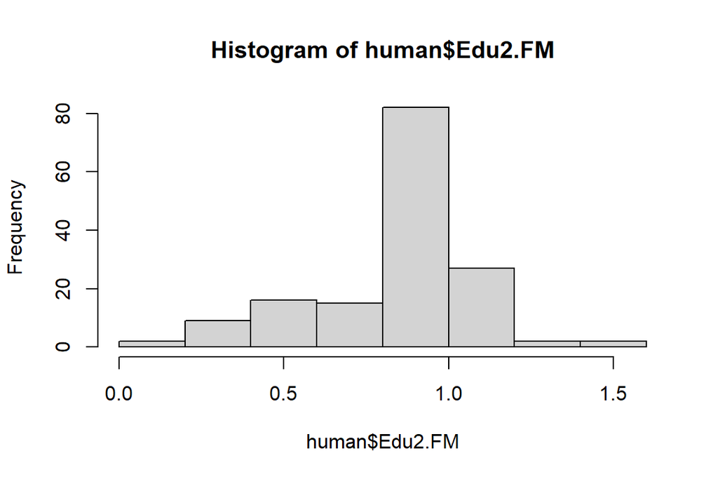

```r
hist(human$Edu2.FM)
```

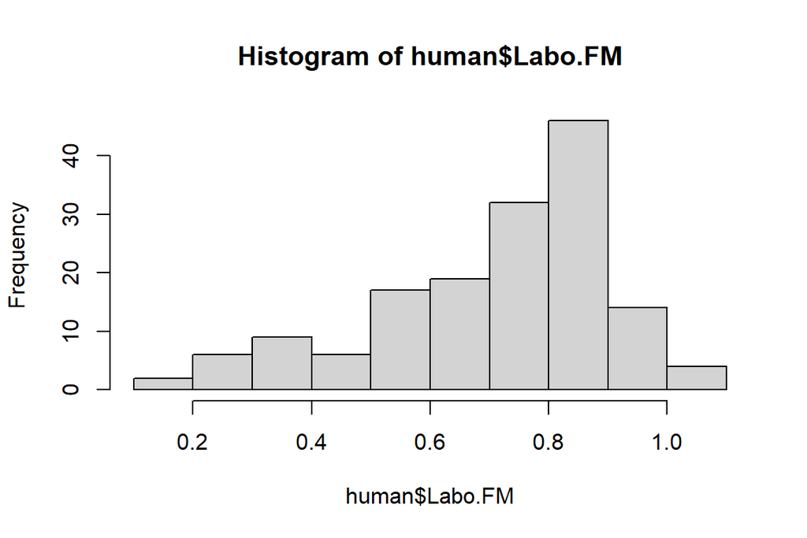

```r
hist(human$Labo.FM)
```

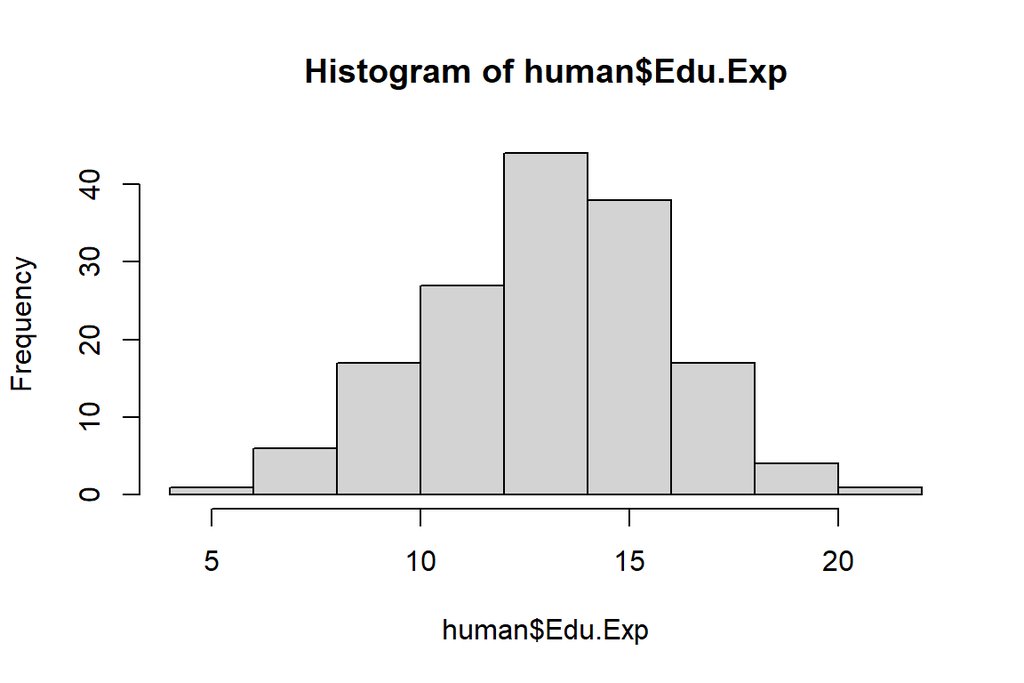

```r
hist(human$Edu.Exp)
```

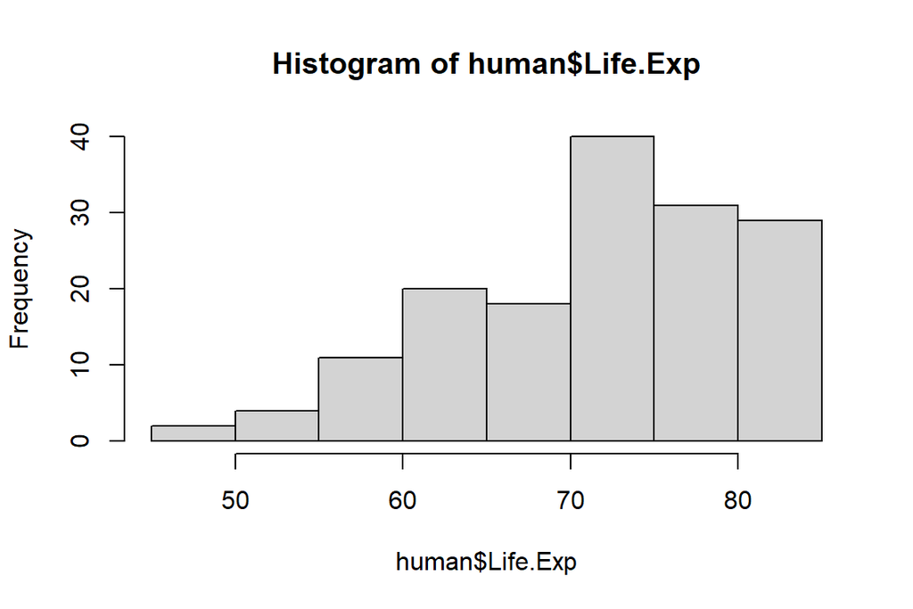

```r
hist(human$Life.Exp)
```

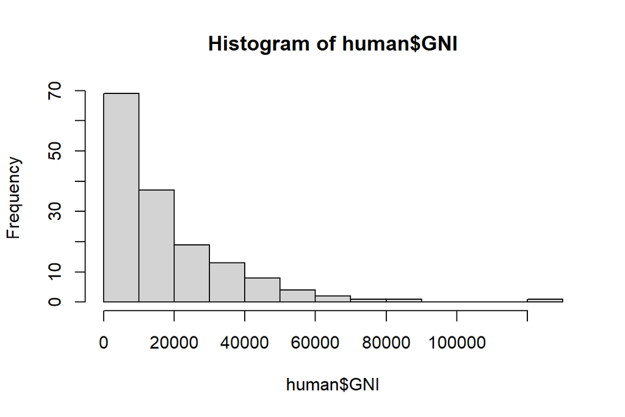

```r
hist(human$GNI)
```

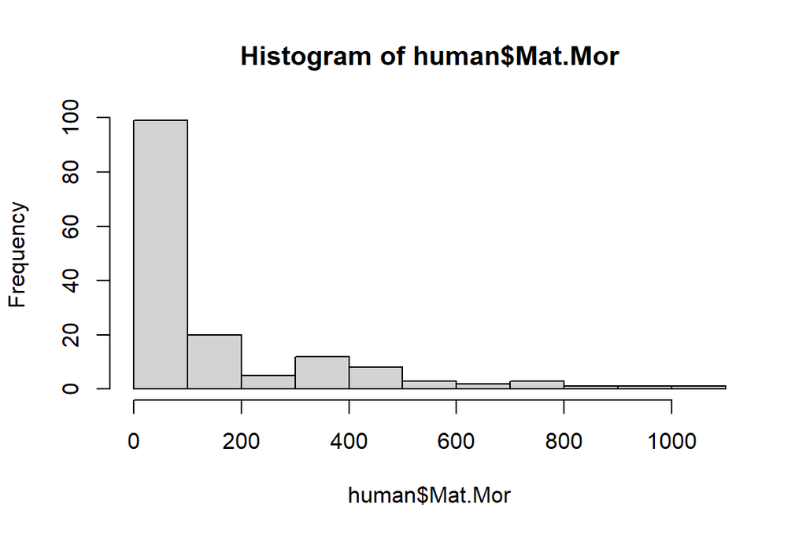

```r
hist(human$Mat.Mor)
```

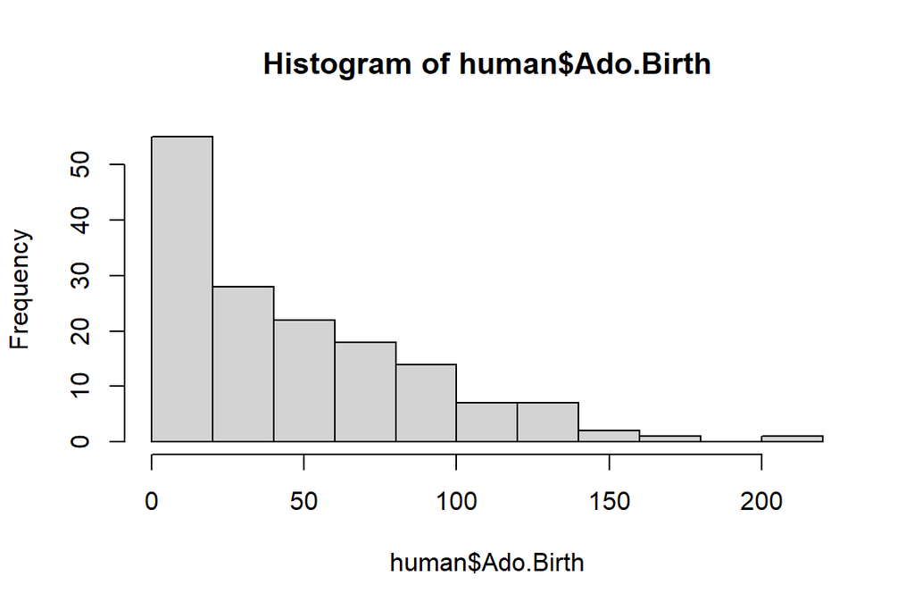

```r
hist(human$Ado.Birth)
```